# IMPORTING LIBRARIES

```python
# importing necessary Python libraries
import numpy as np
import pandas as pd
import seaborn as sns
import plotly.express as px
from matplotlib import pyplot as plt
from tqdm.notebook import tqdm
import os
from PIL import Image
from tqdm import tqdm
from datetime import datetime
import matplotlib.pyplot as plt
from itertools import chain
import plotly.graph_objs as go
#import plotly.figure_factory as ff

# avoid displaying warnings
import warnings
warnings.filterwarnings("ignore")

#import machine learning related libraries
from sklearn.svm import SVC
from sklearn.multioutput import MultiOutputClassifier
from sklearn.ensemble import GradientBoostingClassifier
from sklearn.tree import DecisionTreeClassifier
from sklearn.neighbors import KNeighborsClassifier
from sklearn.naive_bayes import GaussianNB
from sklearn.ensemble import RandomForestClassifier
from sklearn.linear_model import LogisticRegression
from sklearn.model_selection import KFold, cross_val_score, train_test_split, GridSearchCV, cross_validate
from sklearn.metrics import accuracy_score, f1_score, precision_score, recall_score, confusion_matrix
from sklearn.cluster import KMeans
import xgboost as xgb
import time
```

# IMPORTING THE DATAFRAMES

```python
%%time
df_articles = pd.read_csv("articles.csv")
df_customers = pd.read_csv("customers.csv")
df_sample_submission = pd.read_csv("sample_submission.csv")

df_transactions = pd.read_csv("transactions_train.csv")
```

```
CPU times: total: 48.9 s
Wall time: 56.1 s
```

# EDA

## $\color{red}{\text{1. Customers table Exploration}}$

```python
df_customers.info()
print('-------------------------------')
print('-------------------------------')
df_customers.shape[0] - df_customers['customer_id'].nunique()
print("Duplicate values:",df_customers.shape[0] - df_customers['customer_id'].nunique())
```

```
<class 'pandas.core.frame.DataFrame'>
RangeIndex: 1371980 entries, 0 to 1371979
Data columns (total 7 columns):
 #   Column                  Non-Null Count    Dtype
---  ------                  --------------    -----
 0   customer_id             1371980 non-null  object
 1   FN                      476930 non-null   float64
 2   Active                  464404 non-null   float64
 3   club_member_status      1365918 non-null  object
 4   fashion_news_frequency  1355971 non-null  object
 5   age                     1356119 non-null  float64
 6   postal_code             1371980 non-null  object
dtypes: float64(3), object(4)
memory usage: 73.3+ MB
-------------------------------
-------------------------------
Duplicate values: 0
```

#### Customers data description:

customer_id : A unique identifier of every customer  
FN : 1 or missed  
Active : 1 or missed  
club_member_status : Status in club  
fashion_news_frequency : How often H&M may send news to customer  
age : The current age  
postal_code : Postal code of customer

#### We can see there are some null values in customers columns: 'FN','age','Active','club_member_status','fashion_news_frequency'

#### And column 'fashion_news_frequency' has 2 'None' values instead of 'NONE'

#### There are no duplicate values in customers

## Lets Explore some insights about customers

#### i. Number of Customers per each Age

The most common age is about 21-23

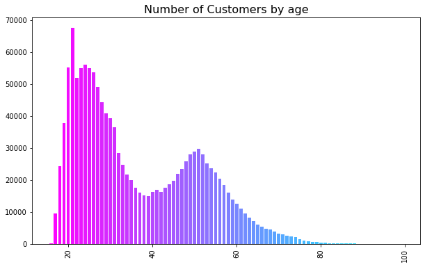

```python
def pie_chart(df, col_values, labels, ax, color, title):
    n_classes = len(df)
    explode = (0.5,) * n_classes # explode for 0.1 each slice
    ax.pie(df[col_values],
           colors=color,
           explode=explode,
           labels=df[labels],
           shadow=True)
    ax.set_title(title, fontsize=16)

def bar_plot(df, col_x, col_y, ax, color, title):
    ax.bar(x=df[col_x],
           height=df[col_y],
           color=color)
    ax.set_title(title, fontsize=16)
    plt.xticks(rotation=90)

temp = df_customers.groupby(["age"])["customer_id"].count()
df = pd.DataFrame({'Age': temp.index,'Customers': temp.values})
df = df.sort_values(['Age'], ascending=False)


fig, axes = plt.subplots(nrows=1, ncols=1, figsize=(10,6))
color = plt.cm.cool(np.linspace(0, 1, len(df)))

bar_plot(df,
         'Age',
         'Customers',
         axes,
         color,
         "Number of Customers by age")
```

#### ii. Customer Status in H&M club.

Almost every customer has an active club status, some of them begin to activate it (pre-create). A tiny part of customers abandoned the club.

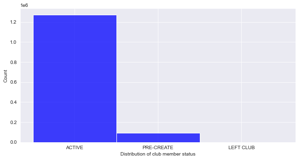

```python
sns.set_style("darkgrid")
f, ax = plt.subplots(figsize=(10,5))
ax = sns.histplot(data=df_customers, x='club_member_status', color='blue')
ax.set_xlabel('Distribution of club member status')
plt.show()
```

## Cleaning the customers table

```python
df_customers = df_customers.dropna(subset=['age'])
df_customers.isna().sum()
```

```
customer_id                    0
FN                        880403
Active                    892890
club_member_status          3776
fashion_news_frequency     13795
age                            0
postal_code                    0
dtype: int64
```

```python
customers_12 = df_transactions.customer_id.value_counts()
```

cutomers who bought more than 12 items

```python
customers_12 > 12
customers_12.index[customers_12 > 12] #
```

```
Index(['be1981ab818cf4ef6765b2ecaea7a2cbf14ccd6e8a7ee985513d9e8e53c6d91b',
       'b4db5e5259234574edfff958e170fe3a5e13b6f146752ca066abca3c156acc71',
       '49beaacac0c7801c2ce2d189efe525fe80b5d37e46ed05b50a4cd88e34d0748f',
       'a65f77281a528bf5c1e9f270141d601d116e1df33bf9df512f495ee06647a9cc',
       'cd04ec2726dd58a8c753e0d6423e57716fd9ebcf2f14ed6012e7e5bea016b4d6',
       '55d15396193dfd45836af3a6269a079efea339e875eff42cc0c228b002548a9d',
       'c140410d72a41ee5e2e3ba3d7f5a860f337f1b5e41c27cf9bda5517c8774f8fa',
       '8df45859ccd71ef1e48e2ee9d1c65d5728c31c46ae957d659fa4e5c3af6cc076',
       '03d0011487606c37c1b1ed147fc72f285a50c05f00b9712e0fc3da400c864296',
       '6cc121e5cc202d2bf344ffe795002bdbf87178054bcda2e57161f0ef810a4b55',
       ...
       'af0cfc7c75f10fae0d2883e7109d1ae72d2cb30df0690f2333ca119f7f0a4bfa',
       'ad9e867cdc219519c7890493f374ec5f6905a4a92bde59a4b10305ebcaa30991',
       '53e83320e341cb09c28419569888f11285c0a072e1482c052cdf649aceb1a9c8',
       'd88e13f0ebb77c64b9ab5b49533ff7c3c8bf7034fb629bd4f2d692d8e4fd05b4',
       'f7200220f78f7177cf8e3e5950999a34ad09a9044019d3438c49fd0b3781a5c3',
       'abadd767836738f13974246aea367ab888bc3751b76b8dd5ba16763f995e0c16',
       'cf0e36a46a7595389af823a257f3df16d27c4c6dc02a039191e4e70b35b333b2',
       '2ea58c604437eb4c2348cfd35c1f0e85a38b2ffe2bac37f8f3accfb5969418d9',
       '7f6aa01bce40d1802a5170be4c38fd5bb8120195ef9d5ec3df1eede36c8a8426',
       'efb11bc7b3f5a81a0baef58593bb95eb88a3576cf983df91a54e4a4988d7bd75'],
      dtype='object', length=583460)
```

```python
# df with list of customer with more than 12 purchases
customer_best = customers_12.index[customers_12 > 12]
customer_best
```

```
Index(['be1981ab818cf4ef6765b2ecaea7a2cbf14ccd6e8a7ee985513d9e8e53c6d91b',
       'b4db5e5259234574edfff958e170fe3a5e13b6f146752ca066abca3c156acc71',
       '49beaacac0c7801c2ce2d189efe525fe80b5d37e46ed05b50a4cd88e34d0748f',
       'a65f77281a528bf5c1e9f270141d601d116e1df33bf9df512f495ee06647a9cc',
       'cd04ec2726dd58a8c753e0d6423e57716fd9ebcf2f14ed6012e7e5bea016b4d6',
       '55d15396193dfd45836af3a6269a079efea339e875eff42cc0c228b002548a9d',
       'c140410d72a41ee5e2e3ba3d7f5a860f337f1b5e41c27cf9bda5517c8774f8fa',
       '8df45859ccd71ef1e48e2ee9d1c65d5728c31c46ae957d659fa4e5c3af6cc076',
       '03d0011487606c37c1b1ed147fc72f285a50c05f00b9712e0fc3da400c864296',
       '6cc121e5cc202d2bf344ffe795002bdbf87178054bcda2e57161f0ef810a4b55',
       ...
       'af0cfc7c75f10fae0d2883e7109d1ae72d2cb30df0690f2333ca119f7f0a4bfa',
       'ad9e867cdc219519c7890493f374ec5f6905a4a92bde59a4b10305ebcaa30991',
       '53e83320e341cb09c28419569888f11285c0a072e1482c052cdf649aceb1a9c8',
       'd88e13f0ebb77c64b9ab5b49533ff7c3c8bf7034fb629bd4f2d692d8e4fd05b4',
       'f7200220f78f7177cf8e3e5950999a34ad09a9044019d3438c49fd0b3781a5c3',
       'abadd767836738f13974246aea367ab888bc3751b76b8dd5ba16763f995e0c16',
       'cf0e36a46a7595389af823a257f3df16d27c4c6dc02a039191e4e70b35b333b2',
       '2ea58c604437eb4c2348cfd35c1f0e85a38b2ffe2bac37f8f3accfb5969418d9',
       '7f6aa01bce40d1802a5170be4c38fd5bb8120195ef9d5ec3df1eede36c8a8426',
       'efb11bc7b3f5a81a0baef58593bb95eb88a3576cf983df91a54e4a4988d7bd75'],
      dtype='object', length=583460)
```

```python
#Taking 10000 rows for sample data undertaking
customer_sample = df_customers[df_customers['customer_id'].isin(customer_best)].sample(n=10000, frac=None, replace=False, weights=None, random_state=1)
```

## $\color{red}{\text{2. Articles table Exploration }}$

```python
df_articles.info()
```

```
<class 'pandas.core.frame.DataFrame'>
RangeIndex: 105542 entries, 0 to 105541
Data columns (total 25 columns):
 #   Column                        Non-Null Count   Dtype
---  ------                        --------------   -----
 0   article_id                    105542 non-null  int64
 1   product_code                  105542 non-null  int64
 2   prod_name                     105542 non-null  object
 3   product_type_no               105542 non-null  int64
 4   product_type_name             105542 non-null  object
 5   product_group_name            105542 non-null  object
 6   graphical_appearance_no       105542 non-null  int64
 7   graphical_appearance_name     105542 non-null  object
 8   colour_group_code             105542 non-null  int64
 9   colour_group_name             105542 non-null  object
```

[output cut: 17 more lines]

#### This table contains all h&m articles with details such as a type of product, a color, a product group and other features.

Article data description:

article_id : A unique identifier of every article.</br> product_code, prod_name : A unique identifier of every product and its name (not the same).</br> product_type, product_type_name : The group of product_code and its name</br> graphical_appearance_no, graphical_appearance_name : The group of graphics and its name</br> colour_group_code, colour_group_name : The group of color and its name</br> perceived_colour_value_id, perceived_colour_value_name, perceived_colour_master_id, perceived_colour_master_name : The added color info</br> department_no, department_name: : A unique identifier of every dep and its name</br> index_code, index_name: : A unique identifier of every index and its name</br> index_group_no, index_group_name: : A group of indeces and its name</br> section_no, section_name: : A unique identifier of every section and its name</br> garment_group_no, garment_group_name: : A unique identifier of every garment and its name</br> detail_desc: : Details</br>

#### Some of the columns have -1 values probably referring to missing data

```python
print("columns having -1 values: \n")
cols_missing_value=[]
for i in df_articles.columns:
    if (-1 in df_articles[i].value_counts()):
        cols_missing_value.append(i)
print(cols_missing_value)
```

```
columns having -1 values:

['product_type_no', 'graphical_appearance_no', 'colour_group_code', 'perceived_colour_value_id', 'perceived_colour_master_id']
```

```python
def missing_data(data):
    total = data.isnull().sum().sort_values(ascending = False)
    percent = (data.isnull().sum()/data.isnull().count()*100).sort_values(ascending = False)
    return pd.concat([total, percent], axis=1, keys=['Total', 'Percent'])
```

```python
missing_data(df_articles).head(7).style.set_properties(**{'background-color': 'rgba(245, 181, 152,.5)'})
```

|  | Total | Percent |
| --- | --- | --- |
| detail_desc | 416 | 0.394156 |
| perceived_colour_master_name | 0 | 0.000000 |
| garment_group_name | 0 | 0.000000 |
| garment_group_no | 0 | 0.000000 |
| section_name | 0 | 0.000000 |
| section_no | 0 | 0.000000 |
| index_group_name | 0 | 0.000000 |

### -1 value in all code columns refer to the 'Unknown' category. Therefore keeping -1 values as it is

## Lets Explore some insights about Articles table

#### i. Ladieswear accounts for a significant part of all dresses. Sportswear has the least portion.

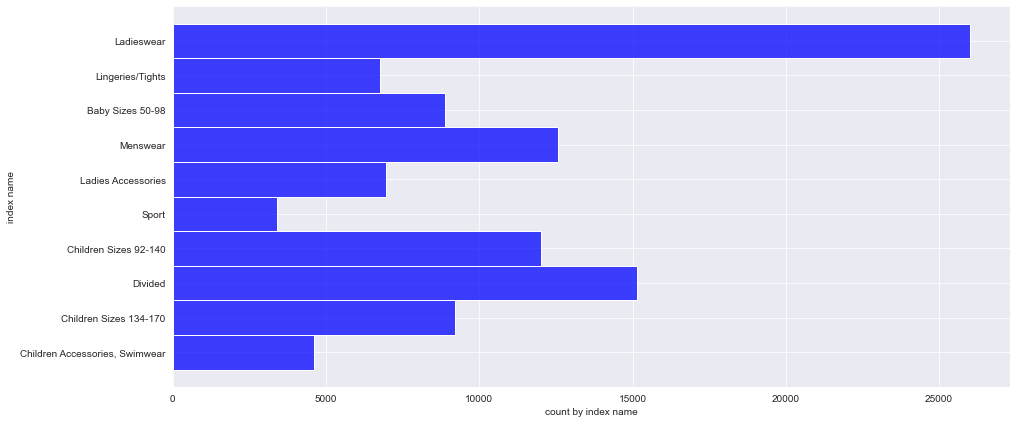

```python
f, ax = plt.subplots(figsize=(15, 7))
ax = sns.histplot(data=df_articles, y='index_name', color='blue')
ax.set_xlabel('count by index name')
ax.set_ylabel('index name')
plt.show()
```

#### ii. Lets see what ladies buys the most

The garments grouped by index: As we can see Jersey fancy is the most frequent garment, especially for women and children. The next by number is accessories, many various accessories with low price.

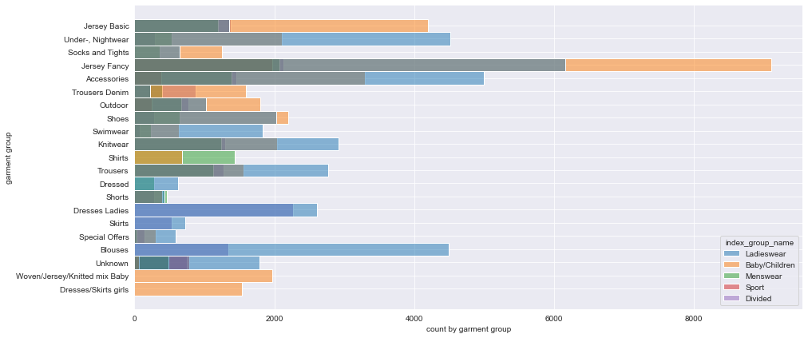

```python
f, ax = plt.subplots(figsize=(15, 7))
ax = sns.histplot(data=df_articles, y='garment_group_name', color='blue', hue='index_group_name')
ax.set_xlabel('count by garment group')
ax.set_ylabel('garment group')
plt.show()
```

# FEATURE SELECTION & FEATURE ENGINEERING

#### Data splitting is among the most critical steps before preprocessing. It is possible to cause data leakage by dividing the data before processing it, or to overestimate the model evaluation when splitting the data. But Splitting data prior to processing has the huge advantage of ensuring consistency in model performance because unseen data are processed in the same manner as test data.

```python
#Split customer sample data (10000 rows) in test and train dataframe
customer_train, customer_test, = train_test_split(customer_sample, test_size=0.3)
```

```python
customer_train.head()
customer_test.shape
customer_train.shape
```

```
(7000, 7)
```

### Data frame df_articles has been cleaned up by removing extra columns. We need to drop a couple of columns from the df_articles data frame since it is extremely large, and we won't be evaluating the machine learning model with those columns.

```python
# remove unwanted columns from articles df and place it into a new df
clean_df_articles = df_articles.drop(columns=['prod_name', 'product_type_name', 'graphical_appearance_name',
                                       'colour_group_name', 'perceived_colour_value_name', 'perceived_colour_master_name', 'department_name',
                                'perceived_colour_value_id', 'perceived_colour_master_id',
                                       'index_name', 'index_group_name', 'section_name', 'garment_group_name'])
```

```python
clean_df_articles.info()
```

```
<class 'pandas.core.frame.DataFrame'>
RangeIndex: 105542 entries, 0 to 105541
Data columns (total 12 columns):
 #   Column                   Non-Null Count   Dtype
---  ------                   --------------   -----
 0   article_id               105542 non-null  int64
 1   product_code             105542 non-null  int64
 2   product_type_no          105542 non-null  int64
 3   product_group_name       105542 non-null  object
 4   graphical_appearance_no  105542 non-null  int64
 5   colour_group_code        105542 non-null  int64
 6   department_no            105542 non-null  int64
 7   index_code               105542 non-null  object
 8   index_group_no           105542 non-null  int64
 9   section_no               105542 non-null  int64
 10  garment_group_no         105542 non-null  int64
 11  detail_desc              105126 non-null  object
dtypes: int64(9), object(3)
memory usage: 9.7+ MB
```

##### From the above cell, we can see that unwated columns have been removed. Additionally, we convert the data types for the article column to categorical to reduce processing time.

```python
clean_df_articles['product_code'] = clean_df_articles.product_code.astype('category')
clean_df_articles['product_type_no'] = clean_df_articles.product_type_no.astype('category')
clean_df_articles['product_group_name'] = clean_df_articles.product_group_name.astype('category')
clean_df_articles['graphical_appearance_no'] = clean_df_articles.graphical_appearance_no.astype('category')
clean_df_articles['colour_group_code'] = clean_df_articles.colour_group_code.astype('category')
clean_df_articles['department_no'] = clean_df_articles.department_no.astype('category')
clean_df_articles['index_code'] = clean_df_articles.product_type_no.astype('category')
clean_df_articles['index_group_no'] = clean_df_articles.index_group_no.astype('category')
clean_df_articles['section_no'] = clean_df_articles.section_no.astype('category')
clean_df_articles['garment_group_no'] = clean_df_articles.garment_group_no.astype('category')
clean_df_articles['detail_desc'] = clean_df_articles.detail_desc.astype('category')
```

```python
clean_df_articles.info()
```

```
<class 'pandas.core.frame.DataFrame'>
RangeIndex: 105542 entries, 0 to 105541
Data columns (total 12 columns):
 #   Column                   Non-Null Count   Dtype
---  ------                   --------------   -----
 0   article_id               105542 non-null  int64
 1   product_code             105542 non-null  category
 2   product_type_no          105542 non-null  category
 3   product_group_name       105542 non-null  category
 4   graphical_appearance_no  105542 non-null  category
 5   colour_group_code        105542 non-null  category
 6   department_no            105542 non-null  category
 7   index_code               105542 non-null  category
 8   index_group_no           105542 non-null  category
 9   section_no               105542 non-null  category
 10  garment_group_no         105542 non-null  category
 11  detail_desc              105126 non-null  category
dtypes: category(11), int64(1)
memory usage: 5.6 MB
```

## Merge df_article and df_transastion table into a new df called article_transactions

```python
article_transactions = df_transactions.merge(clean_df_articles, on='article_id', how='left')
```

```python
article_transactions.info()
```

```
<class 'pandas.core.frame.DataFrame'>
Int64Index: 31788324 entries, 0 to 31788323
Data columns (total 16 columns):
 #   Column                   Dtype
---  ------                   -----
 0   t_dat                    object
 1   customer_id              object
 2   article_id               int64
 3   price                    float64
 4   sales_channel_id         int64
 5   product_code             category
 6   product_type_no          category
 7   product_group_name       category
 8   graphical_appearance_no  category
 9   colour_group_code        category
 10  department_no            category
 11  index_code               category
 12  index_group_no           category
 13  section_no               category
 14  garment_group_no         category
 15  detail_desc              category
dtypes: category(11), float64(1), int64(2), object(2)
memory usage: 2.0+ GB
```

```python
article_transactions.head(2)
```

|  | t_dat | customer_id | article_id | price | sales_channel_id | product_code | product_type_no | product_group_name | graphical_appearance_no | colour_group_code | department_no | index_code | index_group_no | section_no | garment_group_no | detail_desc |
| --- | --- | --- | --- | --- | --- | --- | --- | --- | --- | --- | --- | --- | --- | --- | --- | --- |
| 0 | 2018-09-20 | 000058a12d5b43e67d225668fa1f8d618c13dc232df0ca... | 663713001 | 0.050831 | 2 | 663713 | 283 | Underwear | 1010016 | 9 | 1338 | 283 | 1 | 61 | 1017 | Lace push-up body with underwired, moulded, pa... |
| 1 | 2018-09-20 | 000058a12d5b43e67d225668fa1f8d618c13dc232df0ca... | 541518023 | 0.030492 | 2 | 541518 | 306 | Underwear | 1010016 | 51 | 1334 | 306 | 1 | 61 | 1017 | Lace push-up bras with underwired, moulded, pa... |

## Merge customer training and customer test dataframe which we created earlier with article_transactions df to create a proper Train & Test Df which we will use for our testing and prediction.

```python
# Merge customer_train,test with article_transactions to get train & test dataframe
train = customer_train.merge(article_transactions, on='customer_id', how='inner')
test = customer_test.merge(article_transactions, on='customer_id', how='inner')
```

```python
train.info()
test.info()
```

```
<class 'pandas.core.frame.DataFrame'>
Int64Index: 344231 entries, 0 to 344230
Data columns (total 22 columns):
 #   Column                   Non-Null Count   Dtype
---  ------                   --------------   -----
 0   customer_id              344231 non-null  object
 1   FN                       153011 non-null  float64
 2   Active                   151263 non-null  float64
 3   club_member_status       343608 non-null  object
 4   fashion_news_frequency   343602 non-null  object
 5   age                      344231 non-null  float64
 6   postal_code              344231 non-null  object
 7   t_dat                    344231 non-null  object
 8   article_id               344231 non-null  int64
 9   price                    344231 non-null  float64
```

[output cut: 43 more lines]

```python
train.head(-2)
```

|  | customer_id | FN | Active | club_member_status | fashion_news_frequency | age | postal_code | t_dat | article_id | price | ... | product_type_no | product_group_name | graphical_appearance_no | colour_group_code | department_no | index_code | index_group_no | section_no | garment_group_no | detail_desc |
| --- | --- | --- | --- | --- | --- | --- | --- | --- | --- | --- | --- | --- | --- | --- | --- | --- | --- | --- | --- | --- | --- |
| 0 | 999cee9898cdbaf4b3ca8d7a2829a17aa3996b90361289... | 1.0 | 1.0 | ACTIVE | Regularly | 43.0 | 1d521ec8cc3c96919dc5d4c35f68e05506a40454efc80c... | 2018-10-10 | 469658009 | 0.022017 | ... | 286 | Underwear | 1010020 | 9 | 1334 | 286 | 1 | 61 | 1017 | Hipster briefs in microfibre with lace trims, ... |
| 1 | 999cee9898cdbaf4b3ca8d7a2829a17aa3996b90361289... | 1.0 | 1.0 | ACTIVE | Regularly | 43.0 | 1d521ec8cc3c96919dc5d4c35f68e05506a40454efc80c... | 2018-10-10 | 666382003 | 0.025407 | ... | 252 | Garment Upper body | 1010016 | 12 | 1636 | 252 | 1 | 15 | 1005 | Jersey top with a slightly wider neckline and ... |
| 2 | 999cee9898cdbaf4b3ca8d7a2829a17aa3996b90361289... | 1.0 | 1.0 | ACTIVE | Regularly | 43.0 | 1d521ec8cc3c96919dc5d4c35f68e05506a40454efc80c... | 2018-10-10 | 464297021 | 0.016932 | ... | 286 | Underwear | 1010016 | 8 | 1334 | 286 | 1 | 61 | 1017 | Thong briefs in cotton jersey with a wide lace... |
| 3 | 999cee9898cdbaf4b3ca8d7a2829a17aa3996b90361289... | 1.0 | 1.0 | ACTIVE | Regularly | 43.0 | 1d521ec8cc3c96919dc5d4c35f68e05506a40454efc80c... | 2018-10-10 | 683662005 | 0.013542 | ... | 254 | Garment Upper body | 1010017 | 9 | 1643 | 254 | 2 | 51 | 1002 | Long-sleeved top in soft cotton jersey with ri... |
| 4 | 999cee9898cdbaf4b3ca8d7a2829a17aa3996b90361289... | 1.0 | 1.0 | ACTIVE | Regularly | 43.0 | 1d521ec8cc3c96919dc5d4c35f68e05506a40454efc80c... | 2019-01-06 | 626263004 | 0.025407 | ... | 273 | Garment Lower body | 1010016 | 73 | 8716 | 273 | 4 | 77 | 1005 | Treggings in stretch, denim-look jersey with a... |
| ... | ... | ... | ... | ... | ... | ... | ... | ... | ... | ... | ... | ... | ... | ... | ... | ... | ... | ... | ... | ... | ... |
| 344224 | 9157a54bd66e7a88e782476494d70ef5474b9626665bf9... | NaN | NaN | ACTIVE | NONE | 28.0 | c9f6bb2d8bc7364fa75ccbce954703c69a138fcca62119... | 2020-02-14 | 826500002 | 0.042356 | ... | 252 | Garment Upper body | 1010016 | 12 | 1626 | 252 | 1 | 15 | 1003 | Jumper in a soft, chunky knit containing some ... |
| 344225 | 9157a54bd66e7a88e782476494d70ef5474b9626665bf9... | NaN | NaN | ACTIVE | NONE | 28.0 | c9f6bb2d8bc7364fa75ccbce954703c69a138fcca62119... | 2020-02-14 | 831686003 | 0.067780 | ... | 262 | Garment Upper body | 1010016 | 12 | 1201 | 262 | 1 | 19 | 1007 | Shirt jacket in imitation leather with a colla... |
| 344226 | 9157a54bd66e7a88e782476494d70ef5474b9626665bf9... | NaN | NaN | ACTIVE | NONE | 28.0 | c9f6bb2d8bc7364fa75ccbce954703c69a138fcca62119... | 2020-07-22 | 849214006 | 0.011847 | ... | 274 | Garment Lower body | 1010016 | 9 | 5658 | 274 | 3 | 21 | 1025 | Chino shorts in stretch cotton twill. Regular,... |
| 344227 | 9157a54bd66e7a88e782476494d70ef5474b9626665bf9... | NaN | NaN | ACTIVE | NONE | 28.0 | c9f6bb2d8bc7364fa75ccbce954703c69a138fcca62119... | 2020-07-22 | 855507002 | 0.010153 | ... | 529 | Items | 1010016 | 31 | 3419 | 529 | 1 | 66 | 1019 | Plastic smartphone case with a transparent bac... |
| 344228 | 9157a54bd66e7a88e782476494d70ef5474b9626665bf9... | NaN | NaN | ACTIVE | NONE | 28.0 | c9f6bb2d8bc7364fa75ccbce954703c69a138fcca62119... | 2020-07-22 | 846296006 | 0.011847 | ... | 75 | Accessories | 1010001 | 31 | 3519 | 75 | 1 | 65 | 1019 | Bucket hat in woven fabric with eyelets at the... |

344229 rows × 22 columns

## Convert Column t_dat in both train & test df to proper datetime format

```python
#Convert Column t_dat in both train & test df to proper datetime format
train.t_dat = pd.to_datetime(train.t_dat)
test.t_dat = pd.to_datetime(test.t_dat)
```

```python
# Sort the customer_id values from test & train df
train = train.sort_values(['customer_id', 't_dat'])
test = test.sort_values(['customer_id', 't_dat'])
```

## Get last 12 item buys of all the customers

```python
train_group = train.groupby('customer_id', observed=True).tail(12).index #List of the 12 last index
test_group = test.groupby('customer_id', observed=True).tail(12).index
```

```python
#replaces everything up to groupby in next cell
train.loc[train_group,:]
test.loc[test_group,:]
```

|  | customer_id | FN | Active | club_member_status | fashion_news_frequency | age | postal_code | t_dat | article_id | price | ... | product_type_no | product_group_name | graphical_appearance_no | colour_group_code | department_no | index_code | index_group_no | section_no | garment_group_no | detail_desc |
| --- | --- | --- | --- | --- | --- | --- | --- | --- | --- | --- | --- | --- | --- | --- | --- | --- | --- | --- | --- | --- | --- |
| 106542 | 0001177027259b455f979d85a278e4b280205d4de5cce4... | 1.0 | 1.0 | ACTIVE | Regularly | 31.0 | 9a9d6e1a1a1092815671be3a44a1365b678ac3e51fba4e... | 2020-04-05 | 831429001 | 0.030492 | ... | 286 | Underwear | 1010016 | 9 | 3705 | 286 | 1 | 61 | 1017 | Briefs in soft microfibre designed with the mi... |
| 106543 | 0001177027259b455f979d85a278e4b280205d4de5cce4... | 1.0 | 1.0 | ACTIVE | Regularly | 31.0 | 9a9d6e1a1a1092815671be3a44a1365b678ac3e51fba4e... | 2020-04-05 | 198714001 | 0.016932 | ... | 273 | Garment Lower body | 1010016 | 9 | 2032 | 273 | 1 | 8 | 1005 | 3/4-length leggings in soft, organic cotton je... |
| 106544 | 0001177027259b455f979d85a278e4b280205d4de5cce4... | 1.0 | 1.0 | ACTIVE | Regularly | 31.0 | 9a9d6e1a1a1092815671be3a44a1365b678ac3e51fba4e... | 2020-04-05 | 857725002 | 0.025407 | ... | 265 | Garment Full body | 1010017 | 73 | 2032 | 265 | 1 | 8 | 1005 | Short, fitted dress in organic cotton jersey w... |
| 106545 | 0001177027259b455f979d85a278e4b280205d4de5cce4... | 1.0 | 1.0 | ACTIVE | Regularly | 31.0 | 9a9d6e1a1a1092815671be3a44a1365b678ac3e51fba4e... | 2020-04-05 | 857725002 | 0.025407 | ... | 265 | Garment Full body | 1010017 | 73 | 2032 | 265 | 1 | 8 | 1005 | Short, fitted dress in organic cotton jersey w... |
| 106546 | 0001177027259b455f979d85a278e4b280205d4de5cce4... | 1.0 | 1.0 | ACTIVE | Regularly | 31.0 | 9a9d6e1a1a1092815671be3a44a1365b678ac3e51fba4e... | 2020-05-04 | 863456003 | 0.025407 | ... | 257 | Garment Upper body | 1010016 | 92 | 5832 | 257 | 3 | 26 | 1002 | Short-sleeved polo shirt in piqué made from a ... |
| ... | ... | ... | ... | ... | ... | ... | ... | ... | ... | ... | ... | ... | ... | ... | ... | ... | ... | ... | ... | ... | ... |
| 47373 | fffef3b6b73545df065b521e19f64bf6fe93bfd450ab20... | 1.0 | 1.0 | ACTIVE | Regularly | 29.0 | 47258851e6f73dd2583ef4775814f9b88e43a9e2741c64... | 2020-09-09 | 881919001 | 0.025407 | ... | 252 | Garment Upper body | 1010016 | 11 | 3708 | 252 | 1 | 62 | 1017 | Jumper in a soft rib knit containing some wool... |
| 47374 | fffef3b6b73545df065b521e19f64bf6fe93bfd450ab20... | 1.0 | 1.0 | ACTIVE | Regularly | 29.0 | 47258851e6f73dd2583ef4775814f9b88e43a9e2741c64... | 2020-09-09 | 803757023 | 0.016932 | ... | 272 | Garment Lower body | 1010016 | 13 | 1676 | 272 | 1 | 16 | 1002 | Joggers in lightweight sweatshirt fabric made ... |
| 47375 | fffef3b6b73545df065b521e19f64bf6fe93bfd450ab20... | 1.0 | 1.0 | ACTIVE | Regularly | 29.0 | 47258851e6f73dd2583ef4775814f9b88e43a9e2741c64... | 2020-09-12 | 748269009 | 0.025407 | ... | 254 | Garment Upper body | 1010016 | 12 | 1616 | 254 | 1 | 11 | 1003 | Jumper in a soft, fine-knit viscose blend with... |
| 47376 | fffef3b6b73545df065b521e19f64bf6fe93bfd450ab20... | 1.0 | 1.0 | ACTIVE | Regularly | 29.0 | 47258851e6f73dd2583ef4775814f9b88e43a9e2741c64... | 2020-09-12 | 881919001 | 0.025407 | ... | 252 | Garment Upper body | 1010016 | 11 | 3708 | 252 | 1 | 62 | 1017 | Jumper in a soft rib knit containing some wool... |
| 47377 | fffef3b6b73545df065b521e19f64bf6fe93bfd450ab20... | 1.0 | 1.0 | ACTIVE | Regularly | 29.0 | 47258851e6f73dd2583ef4775814f9b88e43a9e2741c64... | 2020-09-22 | 898573003 | 0.033881 | ... | 258 | Garment Upper body | 1010016 | 9 | 1522 | 258 | 1 | 15 | 1010 | Blouse in a textured weave with covered button... |

36000 rows × 22 columns

## We drop unwanted columns from train and test to get dataframes with customers and their last 12 purchases only.

This will give us a y_truth value which states real purchases by customers.

```python
#train.drop(index=train_group, inplace=True)
#test.drop(index=test_group, inplace=True)
```

```python
y_train = train.loc[train_group,:].groupby('customer_id', observed=True)['article_id'].apply(lambda x: x.tolist())
y_test =  test.loc[test_group,:].groupby('customer_id', observed=True)['article_id'].apply(lambda x: x.tolist())
```

```python
y_train.head(100)
y_test.head(100)
```

```
customer_id
0001177027259b455f979d85a278e4b280205d4de5cce4bb83ccbb8d5dbb4b92    [831429001, 198714001, 857725002, 857725002, 8...
0001420326c217a367048472e05395373c40a039f6fd45cd9e4b3a818d02886a    [566941025, 638114001, 566941002, 617249011, 6...
000a9291e5aa007a10faf2177671a8501dade80e6679218d65f53c1497b17f87    [688728023, 892051002, 776237029, 776237027, 8...
0022ab217d36a559cc54c67544c716a2669d291781253888d0777f5b00a94508    [237347004, 698896002, 708472003, 654100006, 5...
00298ddd026d9961f3dc7151ce179b9ca9efee511cce6e1cea3f37e08f75c695    [719310003, 785444001, 696209004, 721744006, 6...
                                                                                          ...
08749b64f9b18f48114f661783f789f2607e8fbe923792e7b1b4b4ffa4c06efb    [747967002, 747967002, 806605001, 803985002, 5...
087897e73a4243fac6d5b135038944738373f346903c8d7e87179ab7d1ae2d70    [580000002, 529012025, 705732002, 735539002, 7...
087c6116edacbdd2db91091c5bb7af9f1a87ab7b946a182f2024c0d5e7d1f26c    [704029002, 654772001, 755745001, 697564001, 5...
08806d049ae13ff12ce178ed17f45524ac12415f01d55005bd46e66ae82ee352    [699080001, 699080001, 699080001, 723347001, 7...
0893c9f048589b64ce3c2b12a57023b014255c86e755f633499a3e75df8c670f    [757995003, 559616014, 717884004, 795675004, 7...
Name: article_id, Length: 100, dtype: object
```

```python
#create data frame for y_train & y_test to get value for just 1 customer
uno_y_train = y_train.apply(lambda x: x[1])
uno_y_test = y_test.apply(lambda x: x[1])
```

```python
uno_y_train.head()
```

```
customer_id
0000f1c71aafe5963c3d195cf273f7bfd50bbf17761c9199e53dbb81641becd7    685814048
00015c1a121e08bbd2552c15fbbb6e6b19d3bf8f7b6a3d60c6d7be26f06264d6    720125017
00067622de3151a7219b4ed9922def50b51601fbe414183d316697f220aa835e    794455001
0039538fce4ca576d95df3315beb4844837a8701f341f32ce36b08bde380ff40    741220014
00474c7cc0d56d175ec6bd122a6d35c539588fb91a5e4056e9f25845f4844a22    759814009
Name: article_id, dtype: int64
```

```python
uno_y_test.head()
```

```
customer_id
0001177027259b455f979d85a278e4b280205d4de5cce4bb83ccbb8d5dbb4b92    198714001
0001420326c217a367048472e05395373c40a039f6fd45cd9e4b3a818d02886a    638114001
000a9291e5aa007a10faf2177671a8501dade80e6679218d65f53c1497b17f87    892051002
0022ab217d36a559cc54c67544c716a2669d291781253888d0777f5b00a94508    698896002
00298ddd026d9961f3dc7151ce179b9ca9efee511cce6e1cea3f37e08f75c695    785444001
Name: article_id, dtype: int64
```

# Function to get X_train & x_test data frames.

This function will helpfull to finding the features values which will be used for finding accuracy.

```python
def function_features (customers):
        #here we will fetch all the required columns which we will use as features
        features_rows = {'FN' : customers['FN'].iloc[0],
                    'Active' : customers['Active'].iloc[0],
                    'club_member_status' : customers['club_member_status'].iloc[0],
                    'fashion_news_frequency' :customers['fashion_news_frequency'].iloc[0],
                    'age'  : customers['age'].iloc[0],
                    'postal_code' : customers['postal_code'].iloc[0]}
        features_rows['bought_items'] = customers.shape[0] #
        return pd.Series(features_rows)
```

Getting x_train & x_test

```python
from tqdm.notebook import tqdm
tqdm.pandas()

x_train = train.groupby('customer_id', observed=True).progress_apply(function_features) #Apply feat_gen to entire Full_train

x_test  = test.groupby('customer_id', observed=True).progress_apply(function_features)
```

```python
x_train.head()
```

| customer_id | FN | Active | club_member_status | fashion_news_frequency | age | postal_code | bought_items |
| --- | --- | --- | --- | --- | --- | --- | --- |
| 0000f1c71aafe5963c3d195cf273f7bfd50bbf17761c9199e53dbb81641becd7 | 1.0 | 1.0 | ACTIVE | Regularly | 30.0 | 7c902dca60ee0bd0f9030eefd445d11146e8d24835738a... | 136 |
| 00015c1a121e08bbd2552c15fbbb6e6b19d3bf8f7b6a3d60c6d7be26f06264d6 | NaN | NaN | ACTIVE | NONE | 24.0 | 045064bd8b280587884bfe521be1496a3bb2ab227d5262... | 41 |
| 00067622de3151a7219b4ed9922def50b51601fbe414183d316697f220aa835e | NaN | NaN | ACTIVE | NONE | 43.0 | e2be1faa08be684c5ba035bc0c311baefb0d8ef772b59a... | 58 |
| 0039538fce4ca576d95df3315beb4844837a8701f341f32ce36b08bde380ff40 | NaN | NaN | ACTIVE | NONE | 23.0 | da3c58f10df4d0498be8ae259805d0fc7ee2fca9b94535... | 28 |
| 00474c7cc0d56d175ec6bd122a6d35c539588fb91a5e4056e9f25845f4844a22 | NaN | NaN | ACTIVE | NONE | 24.0 | 115ff9b5f5fd9b8e09bade8595f0153cd950b368b5e982... | 16 |

```python
x_test.head()
```

| customer_id | FN | Active | club_member_status | fashion_news_frequency | age | postal_code | bought_items |
| --- | --- | --- | --- | --- | --- | --- | --- |
| 0001177027259b455f979d85a278e4b280205d4de5cce4bb83ccbb8d5dbb4b92 | 1.0 | 1.0 | ACTIVE | Regularly | 31.0 | 9a9d6e1a1a1092815671be3a44a1365b678ac3e51fba4e... | 37 |
| 0001420326c217a367048472e05395373c40a039f6fd45cd9e4b3a818d02886a | NaN | NaN | ACTIVE | NONE | 38.0 | cfce56dfa8dde87e7db24b96b8b6cb46bb940ddabe9de0... | 18 |
| 000a9291e5aa007a10faf2177671a8501dade80e6679218d65f53c1497b17f87 | NaN | NaN | ACTIVE | NONE | 50.0 | 832d75a6bb1d2f5b991034ac8b299c06a6dc476df6bbc0... | 66 |
| 0022ab217d36a559cc54c67544c716a2669d291781253888d0777f5b00a94508 | NaN | NaN | ACTIVE | NONE | 54.0 | fb451a7f66611770f43ee19210a29d27f19002cfcaf5d6... | 37 |
| 00298ddd026d9961f3dc7151ce179b9ca9efee511cce6e1cea3f37e08f75c695 | 1.0 | 1.0 | ACTIVE | Regularly | 43.0 | e23b97f6dc06feaef64b7e0831472db3d5a19c618f9a14... | 16 |

## Now we get the prediction column (y_prediction) for training data

```python
train_prediction = train.groupby(["customer_id"])["article_id"].agg(lambda x: str(x.values[0:12])[1:-1]).reset_index()
```

Lets define a function to get prediction values by splitting all items values.

```python
def articles_padding(x):
    if x:
        xl = x.split()
        x = []
        for xi in xl:
            x.append("0"+xi)
        dimm_x = len(x)
        if dimm_x < 12:
            x.extend(art_list[:12-dimm_x])
        return(" ".join(x))
```

```python
train_prediction["article_id"] = train_prediction["article_id"].apply(lambda x: articles_padding(x))
```

Temporary predictied articles ( we will get proper prediction later.)

```python
train_prediction.head()
```

|  | customer_id | article_id |
| --- | --- | --- |
| 0 | 0000f1c71aafe5963c3d195cf273f7bfd50bbf17761c91... | 0373506019 0661166006 0564309022 0564309022 05... |
| 1 | 00015c1a121e08bbd2552c15fbbb6e6b19d3bf8f7b6a3d... | 0557248001 0665477002 0572400002 0625818002 05... |
| 2 | 00067622de3151a7219b4ed9922def50b51601fbe41418... | 0655271001 0519847024 0519847012 0677049002 07... |
| 3 | 0039538fce4ca576d95df3315beb4844837a8701f341f3... | 0651337001 0661647002 0542695005 0593988001 07... |
| 4 | 00474c7cc0d56d175ec6bd122a6d35c539588fb91a5e40... | 0471714002 0715610012 0634013013 0685814005 04... |

# Now we get the prediction column (y_prediction) for test data

```python
test_prediction = test.groupby(["customer_id"])["article_id"].agg(lambda x: str(x.values[0:12])[1:-1]).reset_index()
```

```python
def articles_padding_test(x):
    if x:
        xl = x.split()
        x = []
        for xi in xl:
            x.append("0"+xi)
        dimm_x = len(x)
        if dimm_x < 12:
            x.extend(art_list[:12-dimm_x])
        return(" ".join(x))
```

```python
test_prediction["article_id"] = test_prediction["article_id"].apply(lambda x: articles_padding_test(x))
```

```python
test_prediction.head()
```

|  | customer_id | article_id |
| --- | --- | --- |
| 0 | 0001177027259b455f979d85a278e4b280205d4de5cce4... | 0810800001 0820032004 0852149001 0851936003 07... |
| 1 | 0001420326c217a367048472e05395373c40a039f6fd45... | 0566941001 0566940004 0651242003 0615797001 03... |
| 2 | 000a9291e5aa007a10faf2177671a8501dade80e667921... | 0562252035 0562252035 0706016015 0706016015 06... |
| 3 | 0022ab217d36a559cc54c67544c716a2669d2917812538... | 0696820002 0681376001 0681376001 0680262007 03... |
| 4 | 00298ddd026d9961f3dc7151ce179b9ca9efee511cce6e... | 0702762006 0708478003 0744712003 0685009007 07... |

# Machine Learning Algorithm to Find accuracy and Predcition of the training and test models.

Before we proceed with ml part , we will need to convert our values in x_train & x_test to one hot encoding because currently we have all the data types as categorical which will be needed to converted to int or float to proceed with predcting accuracy

```python
# remove na's in x_train
x_train.fillna(0)
```

| customer_id | FN | Active | club_member_status | fashion_news_frequency | age | postal_code | bought_items |
| --- | --- | --- | --- | --- | --- | --- | --- |
| 0000f1c71aafe5963c3d195cf273f7bfd50bbf17761c9199e53dbb81641becd7 | 1.0 | 1.0 | ACTIVE | Regularly | 30.0 | 7c902dca60ee0bd0f9030eefd445d11146e8d24835738a... | 136 |
| 00015c1a121e08bbd2552c15fbbb6e6b19d3bf8f7b6a3d60c6d7be26f06264d6 | 0.0 | 0.0 | ACTIVE | NONE | 24.0 | 045064bd8b280587884bfe521be1496a3bb2ab227d5262... | 41 |
| 00067622de3151a7219b4ed9922def50b51601fbe414183d316697f220aa835e | 0.0 | 0.0 | ACTIVE | NONE | 43.0 | e2be1faa08be684c5ba035bc0c311baefb0d8ef772b59a... | 58 |
| 0039538fce4ca576d95df3315beb4844837a8701f341f32ce36b08bde380ff40 | 0.0 | 0.0 | ACTIVE | NONE | 23.0 | da3c58f10df4d0498be8ae259805d0fc7ee2fca9b94535... | 28 |
| 00474c7cc0d56d175ec6bd122a6d35c539588fb91a5e4056e9f25845f4844a22 | 0.0 | 0.0 | ACTIVE | NONE | 24.0 | 115ff9b5f5fd9b8e09bade8595f0153cd950b368b5e982... | 16 |
| ... | ... | ... | ... | ... | ... | ... | ... |
| ffe073666e7eb8b3100afa283ad8d38a773f527617d9f82b11f1cfbd1f51f4fb | 0.0 | 0.0 | ACTIVE | NONE | 24.0 | 202942a5bd29f939c6df6c9ac196988da6a347db92252c... | 41 |
| ffe377e31e08fecfe362501ee7414c6613eb6e7ed472d5911ef2b56fdbc84ef8 | 0.0 | 0.0 | ACTIVE | NONE | 56.0 | 90b3693aa6016d0f26815da87b2e355eb56fdfa08bbf75... | 57 |
| ffe44295c63a13498687134a9e6ee5c57e08d84bfffa0d810821c1181b8873e1 | 1.0 | 1.0 | ACTIVE | Regularly | 18.0 | 8d7697facc5d0719b93bda16f9c78d90ec3e11325fb6ee... | 22 |
| fff627c97a69e53afb4a2b49a3ebf7fa06660afaac959b46e8080849008fe17c | 0.0 | 0.0 | ACTIVE | NONE | 47.0 | ffcfcc22e8f55cbd7361f8aba38a41d422ea43a259b043... | 25 |
| fffb2ba21d4a2f5938d5b955662d81f571f2f30b6741f479b4ab2ebe27c12285 | 1.0 | 1.0 | ACTIVE | Regularly | 17.0 | 889d5c9c40ed8e651ae0927e299722f275d71e9a66aefb... | 15 |

7000 rows × 7 columns

```python
# remove na's in x_test
x_test.fillna(0)
```

| customer_id | FN | Active | club_member_status | fashion_news_frequency | age | postal_code | bought_items |
| --- | --- | --- | --- | --- | --- | --- | --- |
| 0001177027259b455f979d85a278e4b280205d4de5cce4bb83ccbb8d5dbb4b92 | 1.0 | 1.0 | ACTIVE | Regularly | 31.0 | 9a9d6e1a1a1092815671be3a44a1365b678ac3e51fba4e... | 37 |
| 0001420326c217a367048472e05395373c40a039f6fd45cd9e4b3a818d02886a | 0.0 | 0.0 | ACTIVE | NONE | 38.0 | cfce56dfa8dde87e7db24b96b8b6cb46bb940ddabe9de0... | 18 |
| 000a9291e5aa007a10faf2177671a8501dade80e6679218d65f53c1497b17f87 | 0.0 | 0.0 | ACTIVE | NONE | 50.0 | 832d75a6bb1d2f5b991034ac8b299c06a6dc476df6bbc0... | 66 |
| 0022ab217d36a559cc54c67544c716a2669d291781253888d0777f5b00a94508 | 0.0 | 0.0 | ACTIVE | NONE | 54.0 | fb451a7f66611770f43ee19210a29d27f19002cfcaf5d6... | 37 |
| 00298ddd026d9961f3dc7151ce179b9ca9efee511cce6e1cea3f37e08f75c695 | 1.0 | 1.0 | ACTIVE | Regularly | 43.0 | e23b97f6dc06feaef64b7e0831472db3d5a19c618f9a14... | 16 |
| ... | ... | ... | ... | ... | ... | ... | ... |
| ffd9669f4d8fea951d334d87c555410cbcc400b20eea4d9cd30989ff0ed53d12 | 1.0 | 1.0 | ACTIVE | Regularly | 58.0 | 6e15848b97d94c88be0918eeac8d22db1ad2ee7d157f07... | 17 |
| ffddc52a24cd9e170570b48773779eec8ad05bd0cf81639e278ceff3eb7a64d5 | 1.0 | 1.0 | ACTIVE | Regularly | 25.0 | d8bbd6a4b6ae2c2391ca00f713db5eedc07f740d08fc57... | 153 |
| ffe42e2da309097faed4b0544399d193a989dfb6563b811da06bd9812026f72e | 0.0 | 0.0 | ACTIVE | NONE | 26.0 | 84e3333732f7f0e2ba37095feed142246d283f2407e061... | 131 |
| fff3cd00dcafe24af2f15a1620d4d1d194f178c03ca0339bdc5c8a047a8c578a | 0.0 | 0.0 | ACTIVE | NONE | 20.0 | 30a587863ba4b7cf757b7aa794f69b3e199035a79eb1ca... | 14 |
| fffef3b6b73545df065b521e19f64bf6fe93bfd450ab20e02ce5d1e58a8f700b | 1.0 | 1.0 | ACTIVE | Regularly | 29.0 | 47258851e6f73dd2583ef4775814f9b88e43a9e2741c64... | 64 |

3000 rows × 7 columns

## LETS CONVERT 'FN', 'Active', 'club_member_status', 'fashion_news_frequency' columns (these are categorical columns) to binary using one hot encoding in x_train and x_test

```python
# applying the one hot encoding  to our X train and  X test dataframe  for 'FN', 'Active', 'club_member_status', 'fashion_news_frequency' columns
x_train_encoded = pd.get_dummies(x_train, columns=['FN', 'Active', 'club_member_status', 'fashion_news_frequency'])
x_test_encoded = pd.get_dummies(x_test, columns=['FN', 'Active', 'club_member_status', 'fashion_news_frequency'])
```

```python
#lets drop unwated column (postal_code, as it is not needed)
x_train_encoded.drop(['postal_code'], axis=1, inplace=True)
x_test_encoded.drop(['postal_code'], axis=1, inplace=True)
```

```python
x_train_encoded.head()
```

| customer_id | age | bought_items | FN_1.0 | Active_1.0 | club_member_status_ACTIVE | club_member_status_LEFT CLUB | club_member_status_PRE-CREATE | fashion_news_frequency_Monthly | fashion_news_frequency_NONE | fashion_news_frequency_Regularly |
| --- | --- | --- | --- | --- | --- | --- | --- | --- | --- | --- |
| 0000f1c71aafe5963c3d195cf273f7bfd50bbf17761c9199e53dbb81641becd7 | 30.0 | 136 | 1 | 1 | 1 | 0 | 0 | 0 | 0 | 1 |
| 00015c1a121e08bbd2552c15fbbb6e6b19d3bf8f7b6a3d60c6d7be26f06264d6 | 24.0 | 41 | 0 | 0 | 1 | 0 | 0 | 0 | 1 | 0 |
| 00067622de3151a7219b4ed9922def50b51601fbe414183d316697f220aa835e | 43.0 | 58 | 0 | 0 | 1 | 0 | 0 | 0 | 1 | 0 |
| 0039538fce4ca576d95df3315beb4844837a8701f341f32ce36b08bde380ff40 | 23.0 | 28 | 0 | 0 | 1 | 0 | 0 | 0 | 1 | 0 |
| 00474c7cc0d56d175ec6bd122a6d35c539588fb91a5e4056e9f25845f4844a22 | 24.0 | 16 | 0 | 0 | 1 | 0 | 0 | 0 | 1 | 0 |

```python
x_test_encoded.head()
```

| customer_id | age | bought_items | FN_1.0 | Active_1.0 | club_member_status_ACTIVE | club_member_status_LEFT CLUB | club_member_status_PRE-CREATE | fashion_news_frequency_Monthly | fashion_news_frequency_NONE | fashion_news_frequency_Regularly |
| --- | --- | --- | --- | --- | --- | --- | --- | --- | --- | --- |
| 0001177027259b455f979d85a278e4b280205d4de5cce4bb83ccbb8d5dbb4b92 | 31.0 | 37 | 1 | 1 | 1 | 0 | 0 | 0 | 0 | 1 |
| 0001420326c217a367048472e05395373c40a039f6fd45cd9e4b3a818d02886a | 38.0 | 18 | 0 | 0 | 1 | 0 | 0 | 0 | 1 | 0 |
| 000a9291e5aa007a10faf2177671a8501dade80e6679218d65f53c1497b17f87 | 50.0 | 66 | 0 | 0 | 1 | 0 | 0 | 0 | 1 | 0 |
| 0022ab217d36a559cc54c67544c716a2669d291781253888d0777f5b00a94508 | 54.0 | 37 | 0 | 0 | 1 | 0 | 0 | 0 | 1 | 0 |
| 00298ddd026d9961f3dc7151ce179b9ca9efee511cce6e1cea3f37e08f75c695 | 43.0 | 16 | 1 | 1 | 1 | 0 | 0 | 0 | 0 | 1 |

```python
x_train_encoded.count()
```

```
age                                 7000
bought_items                        7000
FN_1.0                              7000
Active_1.0                          7000
club_member_status_ACTIVE           7000
club_member_status_LEFT CLUB        7000
club_member_status_PRE-CREATE       7000
fashion_news_frequency_Monthly      7000
fashion_news_frequency_NONE         7000
fashion_news_frequency_Regularly    7000
dtype: int64
```

uno_y_train.head()

```python
uno_y_train.shape
```

```
(7000,)
```

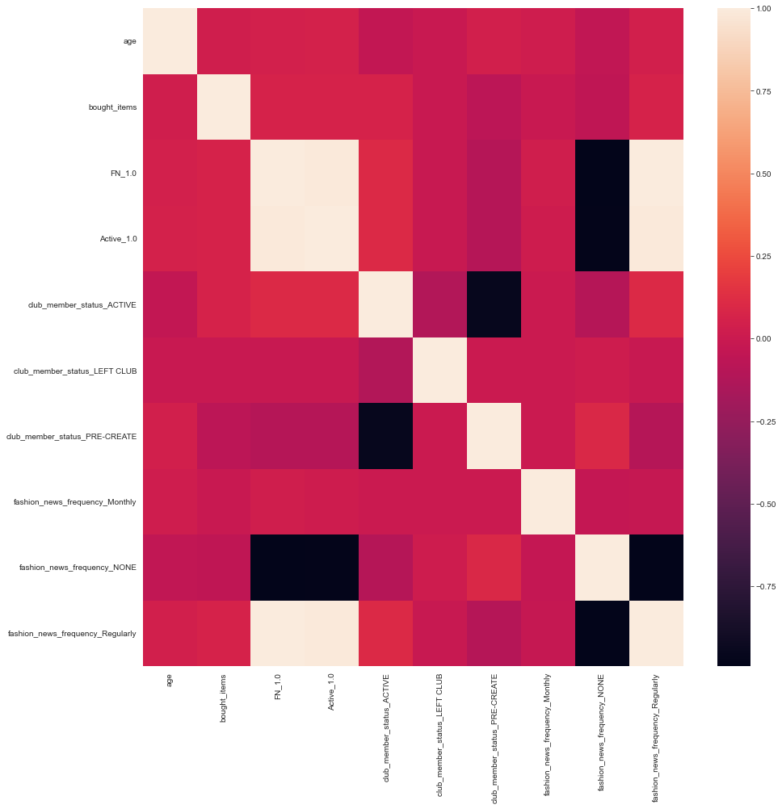

```python
import seaborn as sns
import matplotlib.pyplot as plt
import matplotlib as mpl

plt.figure(figsize=[15,15])
sns.heatmap(x_train_encoded.corr())
plt.show()
```

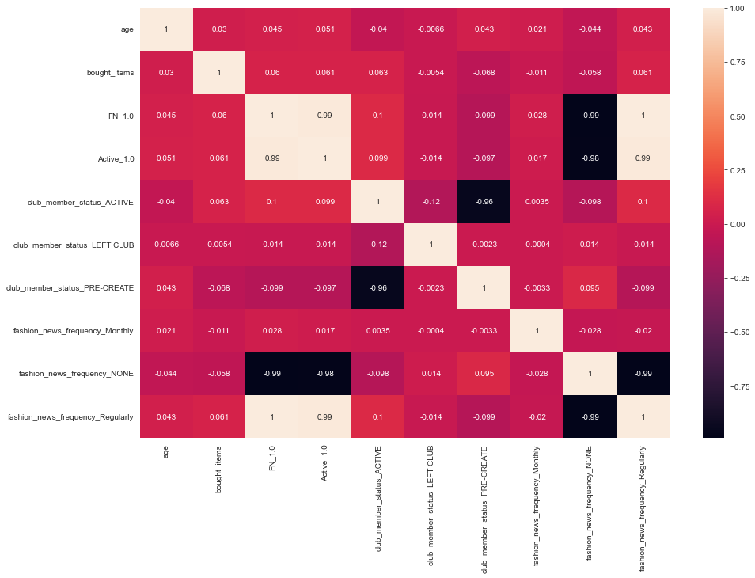

```python
plt.figure(figsize=(15,10))
sns.heatmap(x_train_encoded.corr(), annot=True)
plt.show()
```

```python
x_train_encoded.head()
```

| customer_id | age | bought_items | FN_1.0 | Active_1.0 | club_member_status_ACTIVE | club_member_status_LEFT CLUB | club_member_status_PRE-CREATE | fashion_news_frequency_Monthly | fashion_news_frequency_NONE | fashion_news_frequency_Regularly |
| --- | --- | --- | --- | --- | --- | --- | --- | --- | --- | --- |
| 0000f1c71aafe5963c3d195cf273f7bfd50bbf17761c9199e53dbb81641becd7 | 30.0 | 136 | 1 | 1 | 1 | 0 | 0 | 0 | 0 | 1 |
| 00015c1a121e08bbd2552c15fbbb6e6b19d3bf8f7b6a3d60c6d7be26f06264d6 | 24.0 | 41 | 0 | 0 | 1 | 0 | 0 | 0 | 1 | 0 |
| 00067622de3151a7219b4ed9922def50b51601fbe414183d316697f220aa835e | 43.0 | 58 | 0 | 0 | 1 | 0 | 0 | 0 | 1 | 0 |
| 0039538fce4ca576d95df3315beb4844837a8701f341f32ce36b08bde380ff40 | 23.0 | 28 | 0 | 0 | 1 | 0 | 0 | 0 | 1 | 0 |
| 00474c7cc0d56d175ec6bd122a6d35c539588fb91a5e4056e9f25845f4844a22 | 24.0 | 16 | 0 | 0 | 1 | 0 | 0 | 0 | 1 | 0 |

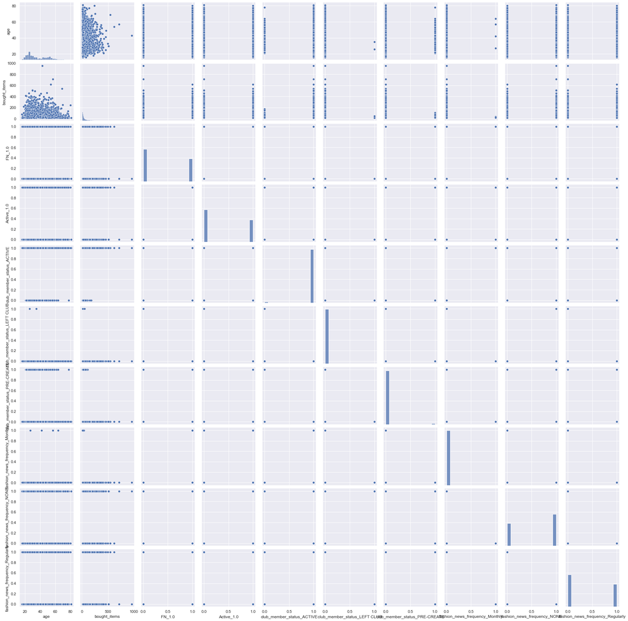

```python
sns.set(font_scale = 1)
sns.pairplot(x_train_encoded)
```

We can see that all categorical columns are now converted to binary 1's & 0's to make our job easier to get accuracy

## Now lets find accuracy using customers data which we did to get a value